# Exploration des simulations de stades phénologiques

## III - Effet des modèles sur les 2 périodes :

Nous allons à présent analyser l’effet des modèles et de l’origine des données climatiques sur les durées des périodes phénologiques simulées.

### Dormance :

Cette période allant du 1 septembre au jour de débourrement, s’interesser à sa durée revient à regarder les dates de débourrement, comme nous l’avons déja fait.

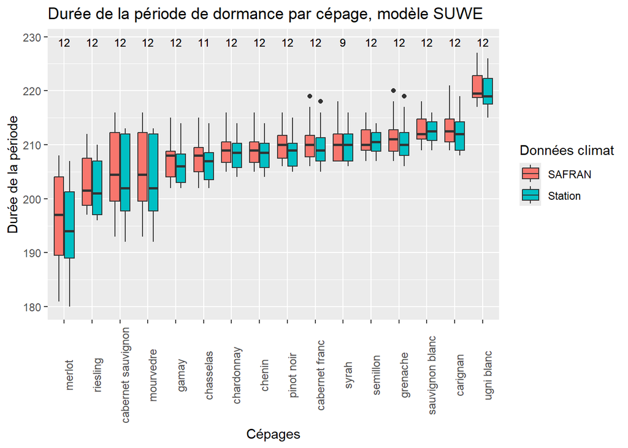

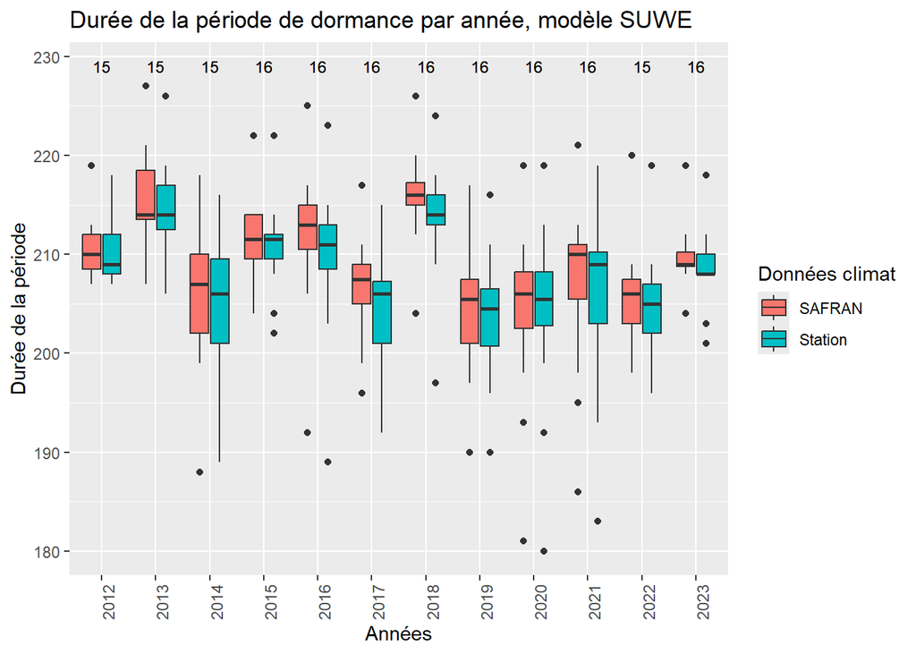

Comme observé précedemment, les données climatiques SAFRAN engendre un débourrement plus tardif.

### Débourrement à floraison :

Pour le modèle gfv, on se base sur la date de debourrement simulée par SUWE car c’est ce que l’on fera dans notre modélisation par la suite. Pour cette même raison, on ne prends en compte ici que les prédictions via les données SAFRAN :

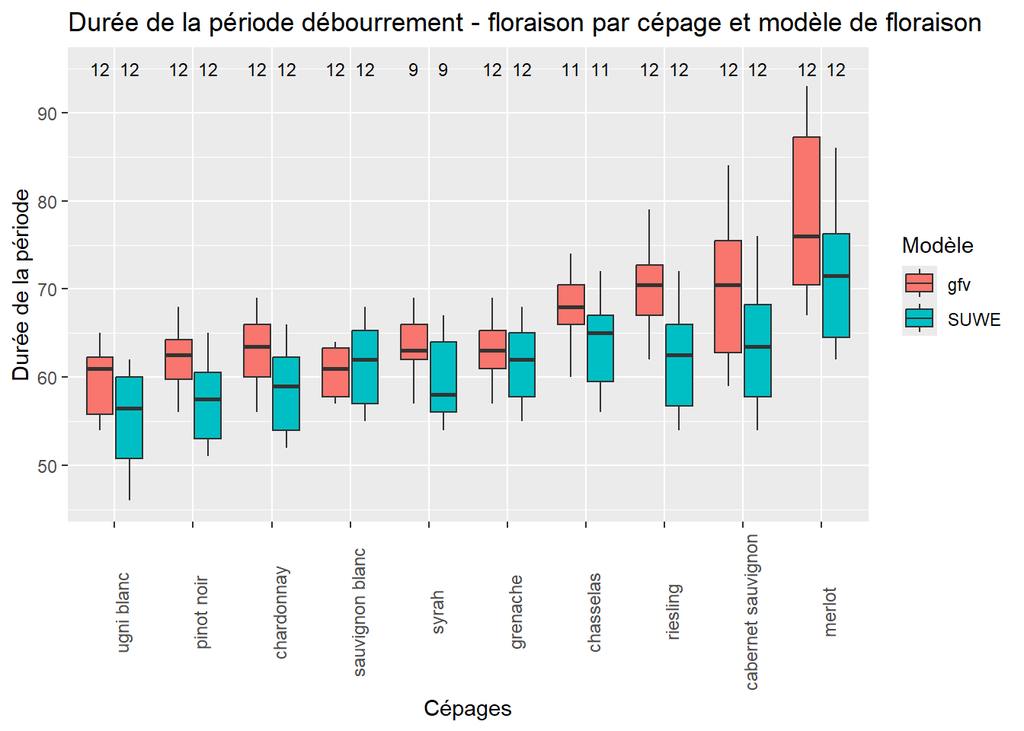

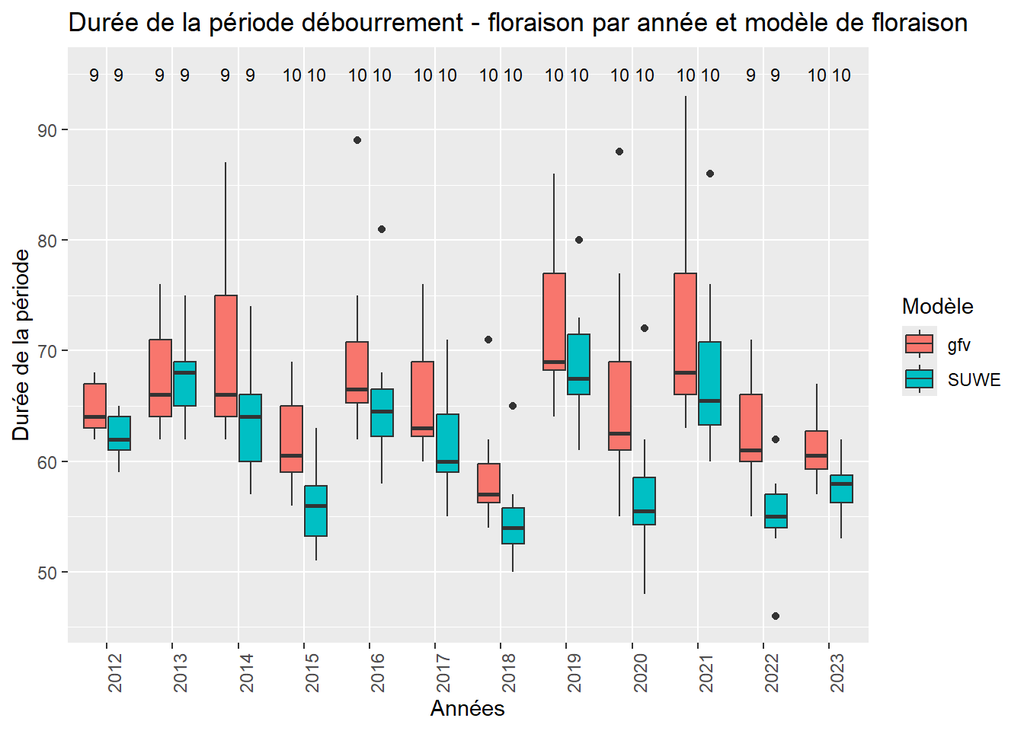

Il existe aussi une réelle variabilité de durée de période inter cépages, mais aussi inter annuelles.

Nous allons à présent regarder la différence entre les durées des périodes simulées, et celle des périodes observées sur la parcelle vitadapt :

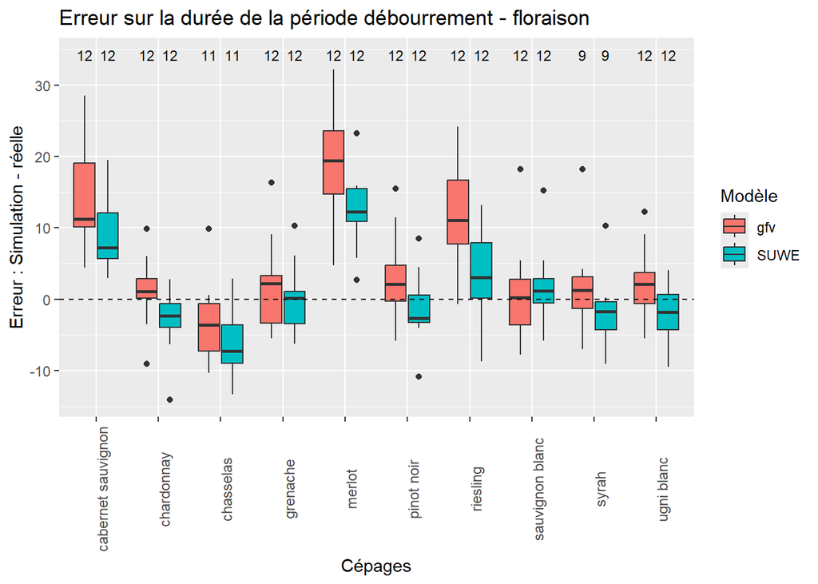

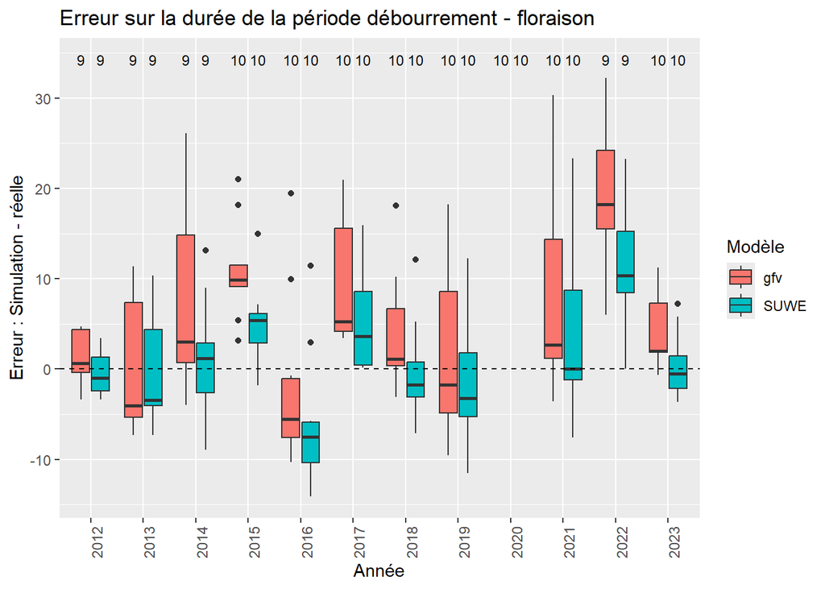

```
## [1] "rmse période gfv :  10.97"
```

```
## [1] "Moyenne erreurs période gfv :  5.66"
```

```
## [1] "rmse période SUWE :  7.69"
```

```
## [1] "Moyenne période erreurs SUWE :  1.6"
```

Nous pouvons observer que pour les cépages où l’erreur sur la date de débourrement est la plus forte, sont aussi ceux avec le plus grand écart entre la durée de la période simulée et celle observée.

Aussi, les erreurs sont plus importantes pour le modèle gfv : Ici, nous prenons la date de débourrement du modèle SUWE, or le modèle gfv se base sur une date fixe : le 1er mars. Les durées seront donc ici plus longue pour le modèle gfv.

Aussi, le fait que les prédictions du modèle SUWE soit trop précoces pour le débourrement et la floraison se compense en partie ici, la durée de la période est assez bien simulées pour une partie des cépages.

### Période de symptôme :

La durée de la période d’observation des symptômes d’ESCA (floraison-31 août) dépend uniquement de la date de floraison.

(31 août = 243 ou 244 ème jours, on prendra 243 ici).

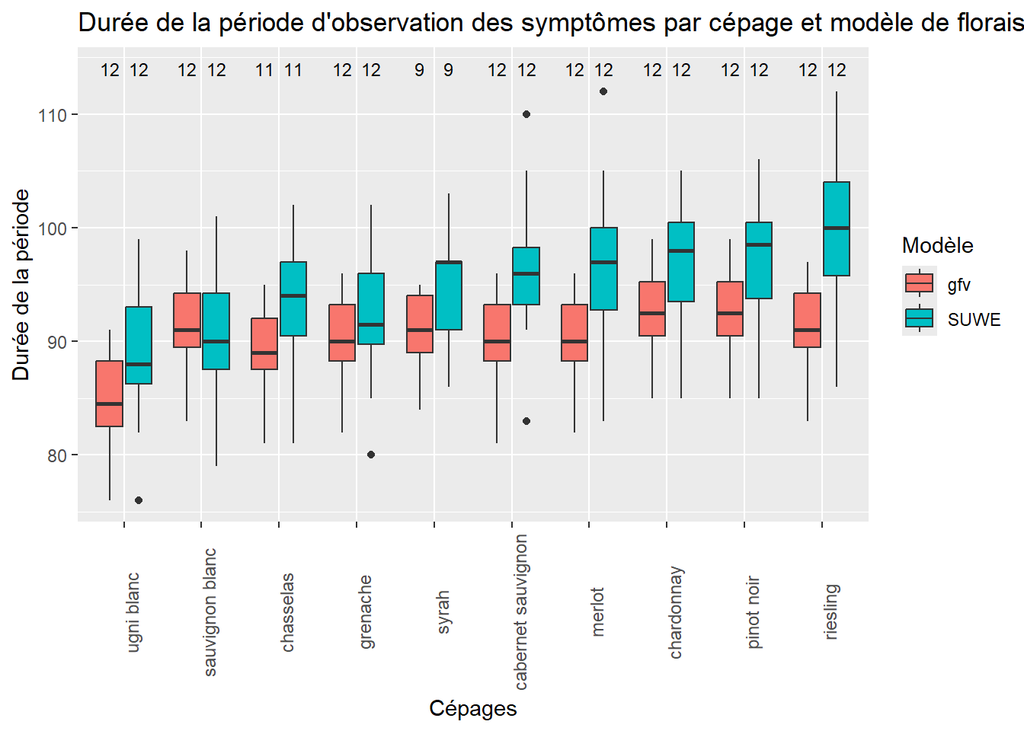

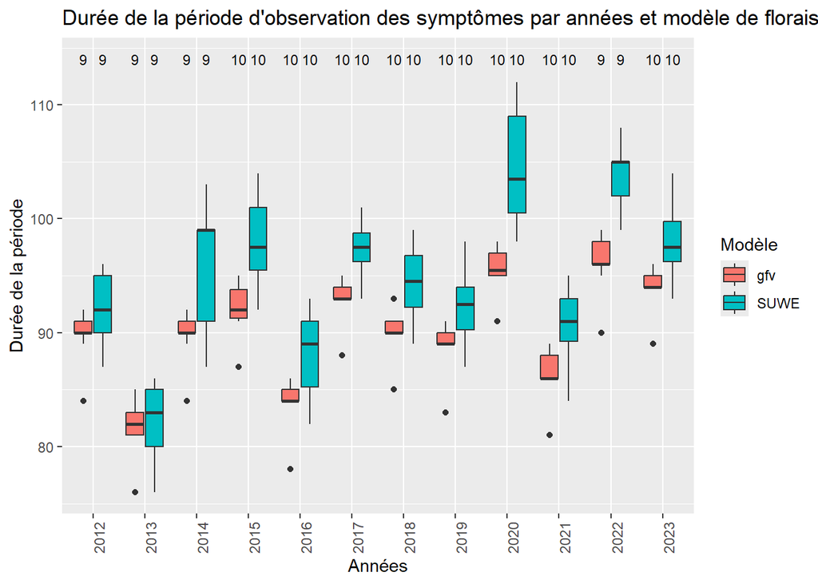

Comme observé précedemment, le modèle SUWE engendre une floraison plus précoce, donc la période floraison - 31 août est plus longue avec ce modèle qu’avec le modèle gfv.

On a vu que les données climatiques SAFRAN engendre une phénologie plus tardive (un peu plus d’un jours), pour le débourrement comme la floraison. Donc la période de dormance est un jour plus longue avec les données SAFRAN, on observe la même durée de période débourrement - floraison, et la période d’observation des symptômes sera un jour plus courte avec les donnés climatiques SAFRAN qu’avec les données climatiques observées de la parcelle vitadapt.